## Agenda

- overview of most common techniques and applications
- training of machine learning models
- assessment or measuring the performance of the models
- basic introduction to:
  - classification
  - regression
  - clustering

## Outcome

- identify problems to be solved
- use appropriate machine learning technique
- interpret the results

## More Applications

- shopping basket analysis
- customer segmentations
- image classification
- text classification
- recommender systems
- credit risk scorecards
- customer churn prediction
- HR attrition analysis

## Decision Tree

- simple to understand and interpret
- requires little data preparation. (No need for normalization or dummy vars, works with NAs)
- works with both numerical and categorical data.
- possible to validate a model using statistical tests.
- robust - performs well even if you deviate from assumptions
- scales to big data

## Recursive Partitioning

- given a subset of training data, find the best feature for predicting the labels on that subset.
- find a split on that feature that best seperates the labels, and split into two new subsets
- repeat steps one and two recursively until you meet a stopping criterion

## Popular Algorithms

- ID3 (Iterative Dichotomiser 3)
- C4.5 (successor of ID3)
- CART (Classification And Regression Tree)
- CHAID (CHi-squared Automatic Interaction Detector). …
- MARS: extends decision trees to handle numerical data better.
- Conditional Inference Trees.

## Libraries

```r
library(readr)
library(dplyr)
library(party)
library(rpart)
library(rpart.plot)
```

## Titanic Data

Each row in the data is a passenger. Columns are features:

- survived: 0 if died, 1 if survived
- embarked: Port of Embarkation (Cherbourg, Queenstown,Southampton)
- sex: Gender
- sibsp: Number of Siblings/Spouses Aboard
- parch: Number of Parents/Children Aboard
- fare: Fare Payed

## Read Data

```r
titanic <-
  read_csv("data/titanic.txt") %>% # read in the data
  select(survived, embarked, sex,
         sibsp, parch, fare) %>%
  mutate(embarked = factor(embarked),
         sex = factor(sex))
```

## Training & Test Data

```r
data <- c("training", "test") %>%
  sample(nrow(titanic), replace = T) %>%
  split(titanic, .)

train <- data$training
test <- data$test
```

## Fit Tree

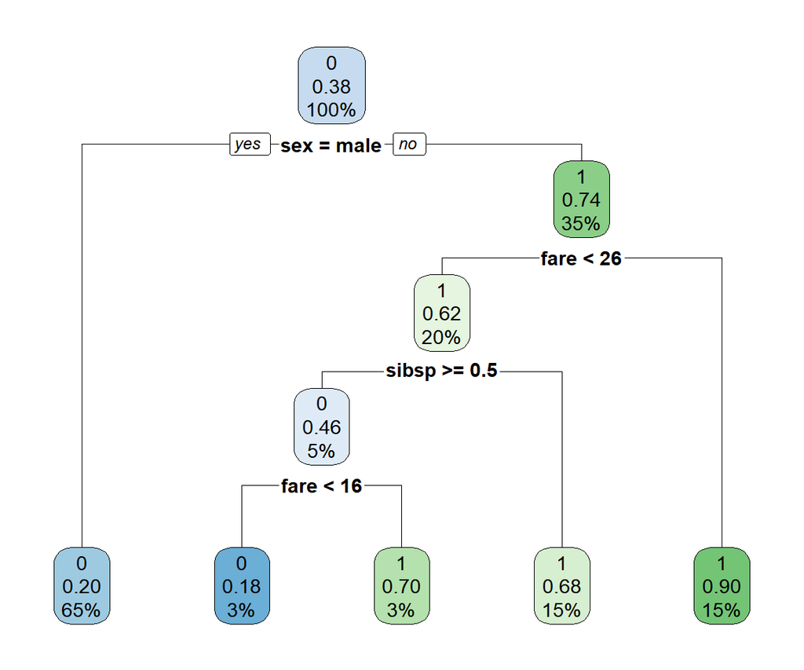

```r
rtree_fit <- rpart(survived ~ ., data = train, method = "class")
rpart.plot(rtree_fit)
```

## Cluster Analysis

## iris

```r
iris
```

```
##     Sepal.Length Sepal.Width Petal.Length Petal.Width    Species
## 1            5.1         3.5          1.4         0.2     setosa
## 2            4.9         3.0          1.4         0.2     setosa
## 3            4.7         3.2          1.3         0.2     setosa
## 4            4.6         3.1          1.5         0.2     setosa
## 5            5.0         3.6          1.4         0.2     setosa
## 6            5.4         3.9          1.7         0.4     setosa
## 7            4.6         3.4          1.4         0.3     setosa
## 8            5.0         3.4          1.5         0.2     setosa
## 9            4.4         2.9          1.4         0.2     setosa
## 10           4.9         3.1          1.5         0.1     setosa
## 11           5.4         3.7          1.5         0.2     setosa
## 12           4.8         3.4          1.6         0.2     setosa
## 13           4.8         3.0          1.4         0.1     setosa
## 14           4.3         3.0          1.1         0.1     setosa
```

[output cut: 136 more lines]

```r
# remove the Species column
iris2 <- iris[-5]
```

## Count of species

```r
species <- iris$Species
table(species)
```

```
## species
##     setosa versicolor  virginica
##         50         50         50
```

## kmeans

```r
km_iris <- kmeans(iris2, 3)
km_iris
```

```
## K-means clustering with 3 clusters of sizes 50, 38, 62
##
## Cluster means:
##   Sepal.Length Sepal.Width Petal.Length Petal.Width
## 1     5.006000    3.428000     1.462000    0.246000
## 2     6.850000    3.073684     5.742105    2.071053
## 3     5.901613    2.748387     4.393548    1.433871
##
## Clustering vector:
##   [1] 1 1 1 1 1 1 1 1 1 1 1 1 1 1 1 1 1 1 1 1 1 1 1 1 1 1 1 1 1 1 1 1 1 1 1
##  [36] 1 1 1 1 1 1 1 1 1 1 1 1 1 1 1 3 3 2 3 3 3 3 3 3 3 3 3 3 3 3 3 3 3 3 3
##  [71] 3 3 3 3 3 3 3 2 3 3 3 3 3 3 3 3 3 3 3 3 3 3 3 3 3 3 3 3 3 3 2 3 2 2 2
## [106] 2 3 2 2 2 2 2 2 3 3 2 2 2 2 3 2 3 2 3 2 2 3 3 2 2 2 2 2 3 2 2 2 2 3 2
## [141] 2 2 3 2 2 2 3 2 2 3
##
## Within cluster sum of squares by cluster:
## [1] 15.15100 23.87947 39.82097
##  (between_SS / total_SS =  88.4 %)
##
## Available components:
##
## [1] "cluster"      "centers"      "totss"        "withinss"
## [5] "tot.withinss" "betweenss"    "size"         "iter"
## [9] "ifault"
```

## Compare Counts

```r
table(km_iris$cluster, species)
```

```
##    species
##     setosa versicolor virginica
##   1     50          0         0
##   2      0          2        36
##   3      0         48        14
```

## Clusters

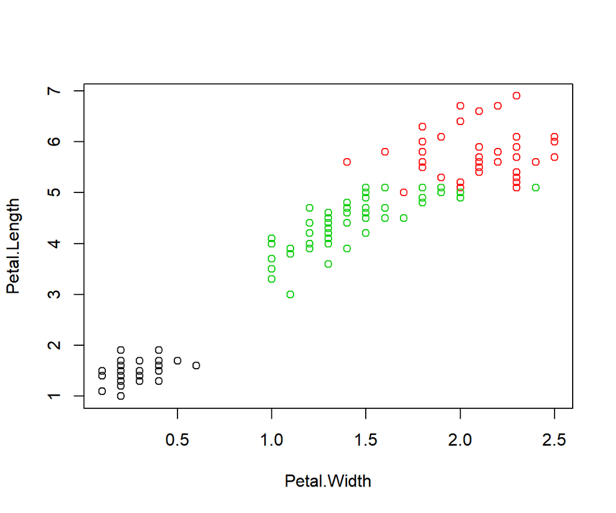

```r
plot(Petal.Length ~ Petal.Width, data = iris2, col = km_iris$cluster)
```

## mtcars

```r
mt <- select(mtcars, hp, wt)
```

## kmeans

```r
km_mtcars <- kmeans(mt, 2)
km_mtcars$cluster
```

```
##           Mazda RX4       Mazda RX4 Wag          Datsun 710
##                   1                   1                   1
##      Hornet 4 Drive   Hornet Sportabout             Valiant
##                   1                   1                   1
##          Duster 360           Merc 240D            Merc 230
##                   2                   1                   1
##            Merc 280           Merc 280C          Merc 450SE
##                   1                   1                   1
##          Merc 450SL         Merc 450SLC  Cadillac Fleetwood
##                   1                   1                   2
## Lincoln Continental   Chrysler Imperial            Fiat 128
##                   2                   2                   1
##         Honda Civic      Toyota Corolla       Toyota Corona
##                   1                   1                   1
##    Dodge Challenger         AMC Javelin          Camaro Z28
##                   1                   1                   2
##    Pontiac Firebird           Fiat X1-9       Porsche 914-2
##                   1                   1                   1
##        Lotus Europa      Ford Pantera L        Ferrari Dino
##                   1                   2                   1
##       Maserati Bora          Volvo 142E
##                   2                   1
```

## Clusters & Centroids

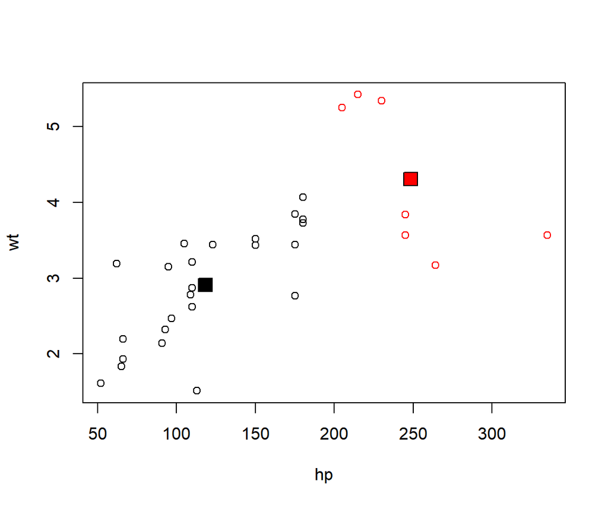

```r
plot(mt, col = km_mtcars$cluster)
points(km_mtcars$centers, pch = 22, bg = c(1, 2), cex = 2)
```

## Linear Regression

- linear regression model
- varaible selection procedures
- residual diagnostics
- multicollinearity
- heteroskedasticity
- prediction

## Logistic Regression

- bivariate analysis
- logistic regression model
- model fit statistics
- variable selection procedures
- model validation